# Cross-cohort Bulk RNA-seq Analysis: Differential expression and functional enrichment

## Reactome

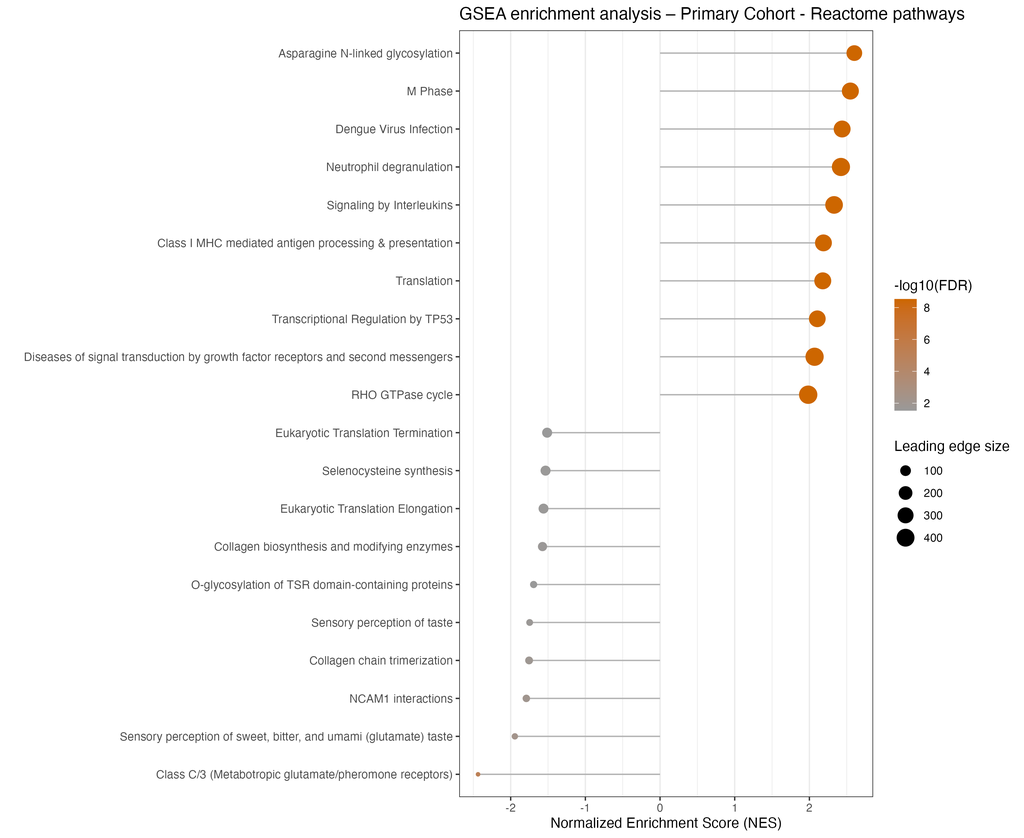

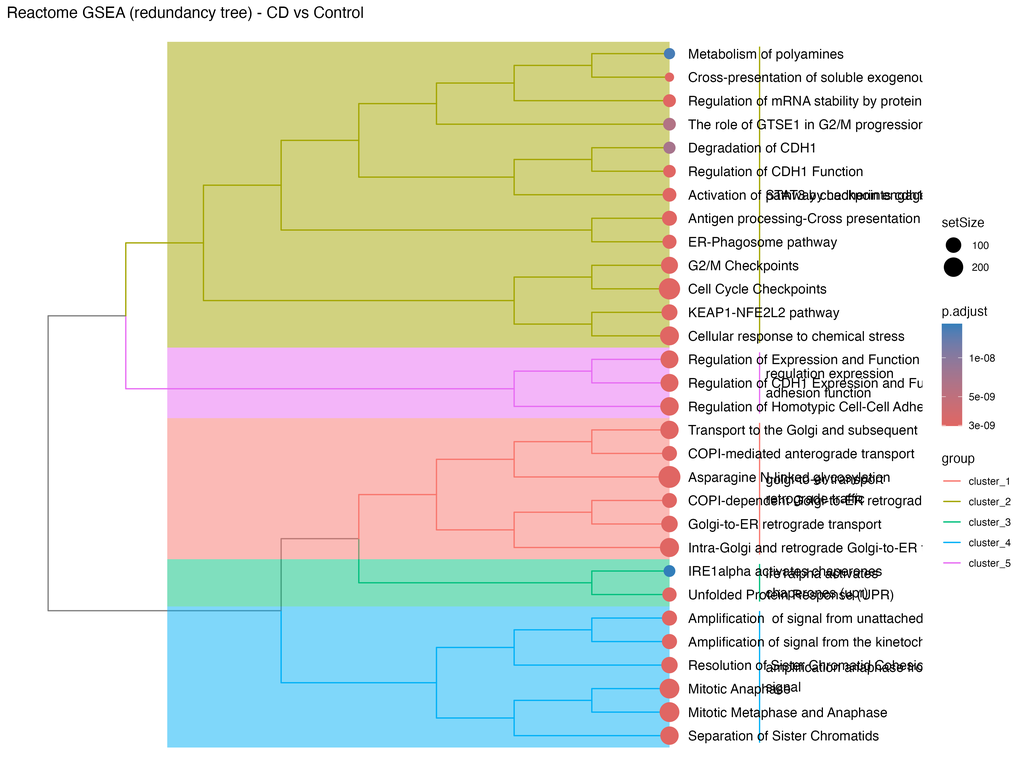

## Biological interpretation

Reactome GSEA further supports activation of immune and cytokine-associated signaling in CD. Enrichment of “Class I MHC mediated antigen processing & presentation” is of particular note, as it independently converges with the MHC-I finding identified as broadly present across both IEL and LPL compartments by CellChat and LIANA in the single-cell analysis of this project - the clearest point of direct, name-level convergence between the bulk and single-cell communication layers. The co-occurrence of “Degradation of CDH1 (endosomes)” and “Regulation of CDH1 Function” among the enriched Reactome terms, together with “cadherin binding” as the top GO Molecular Function term, is also directionally consistent with CDH1 being identified as the most biologically specific CellChat finding in the IEL compartment, although leading-edge gene identity should be verified before treating this as a confirmed convergence.

This interpretation is consistent with previous studies demonstrating increased interferon activity in Crohn’s disease intestinal tissue and with the established role of Th1/IFN-gamma-associated signaling in CD pathogenesis.

## KEGG

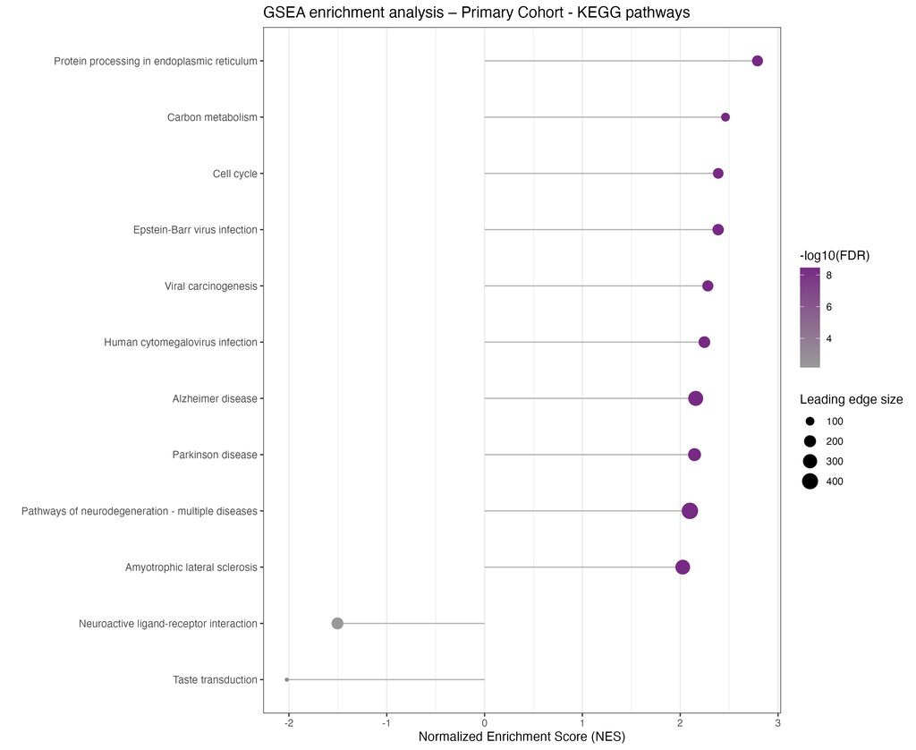

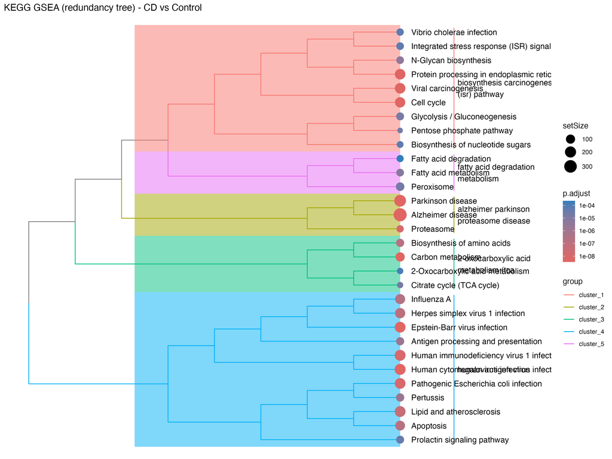

## Biological interpretation

KEGG GSEA identifies a broad activation of immune and inflammatory signaling together with changes in cellular metabolic programs. Multiple infection-associated KEGG terms are represented, but these should not be interpreted as evidence of active infection because such pathways contain shared host-response genes involved in cytokine signaling, antigen presentation and innate immune activation. The overall KEGG profile therefore supports a disease-associated immune activation state rather than a pathogen-specific transcriptional signature.

## Hallmarks Collection H

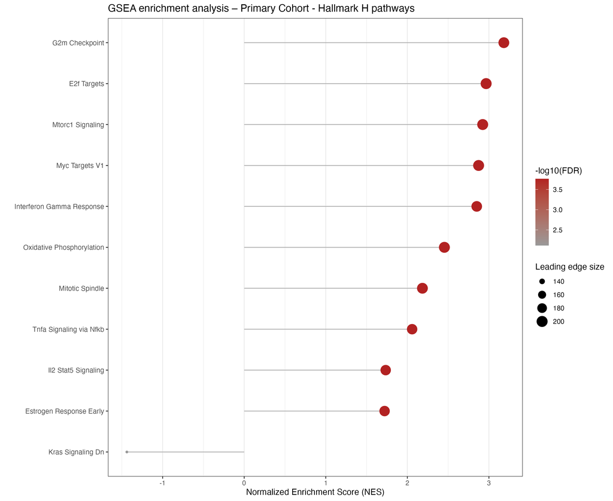

## Biological interpretation

Hallmark GSEA provides the clearest summary of the primary transcriptional phenotype. The strongest positively enriched programs include IFN-gamma response, TNFA signaling via NF-kB and IL2–STAT5 signaling, supporting a coordinated inflammatory and immune-activation state in CD. In parallel, enrichment of G2M checkpoint, E2F targets, MYC targets and mitotic spindle programs indicates increased representation of proliferative and cell-cycle-associated transcriptional programs. mTORC1 signaling and oxidative phosphorylation further suggest altered metabolic activity accompanying the inflammatory state. The convergence of inflammatory, proliferative and metabolic programs is consistent with the complex tissue-level transcriptional remodeling observed in intestinal CD.

**Sensitivity Cohort**

## GO

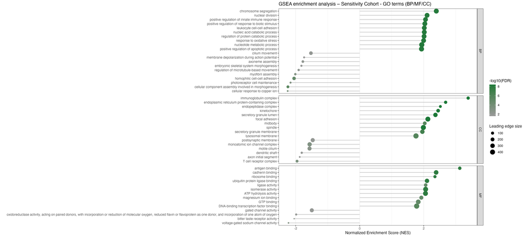

## Biological interpretation

GO GSEA identifies a coordinated enrichment of cell-cycle and immune-related biological processes in the sensitivity cohort. Positively enriched terms include chromosome segregation, nuclear division and other processes associated with cellular proliferation, together with processes related to immune regulation and responses to external stimuli. This indicates that the broader CD cohort is characterized not only by inflammatory activation but also by substantial transcriptional remodeling of proliferative and cellular-state programs. The enrichment of proliferation-associated processes is biologically consistent with the increased proliferative activity reported in Crohn’s disease intestinal mucosa, particularly in regenerating crypt compartments.

## Reactome

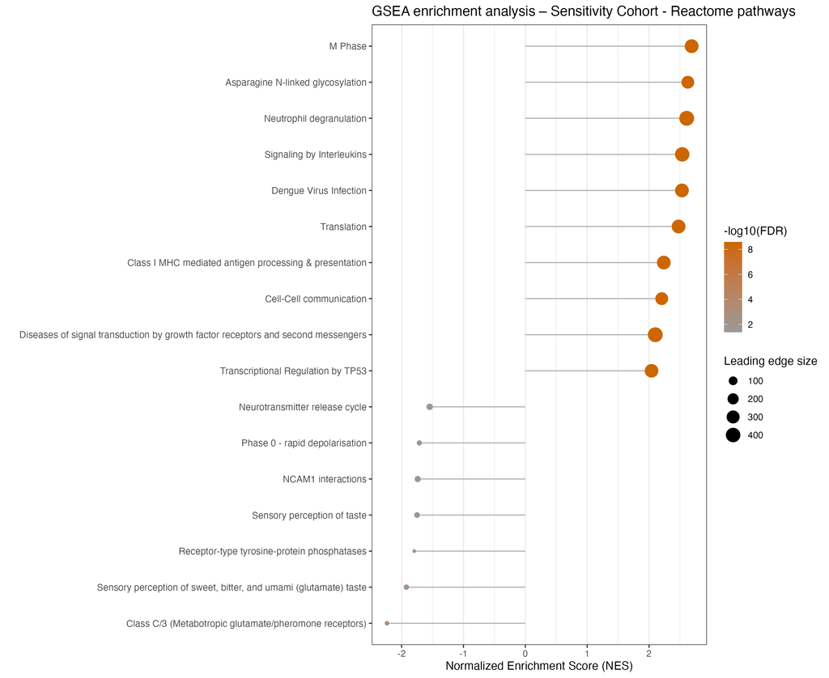

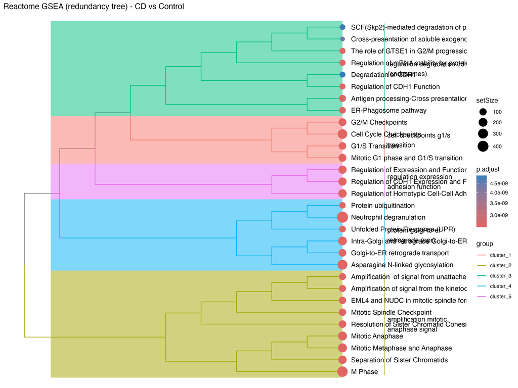

## Biological interpretation

Reactome GSEA further supports the coexistence of immune activation and proliferative remodeling in the sensitivity cohort. Enriched pathways include processes related to cell-cycle progression together with immune signaling and antigen-processing-associated functions, indicating coordinated changes in both cellular proliferation and immune activity. This pattern is consistent with the established inflammatory environment of Crohn’s disease, where activation of mucosal immune pathways occurs together with epithelial and tissue remodeling. The Reactome results therefore reinforce the interpretation obtained from GO GSEA, while providing a pathway-level representation of the same broader inflammatory and proliferative phenotype.

## KEGG

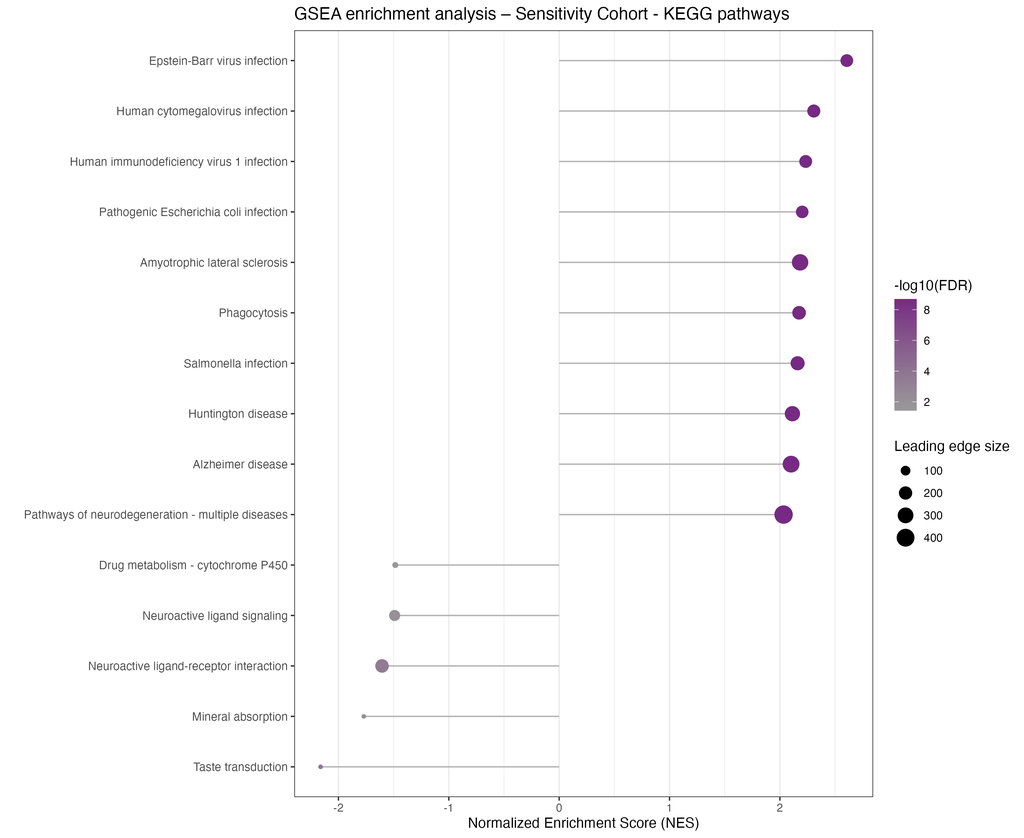

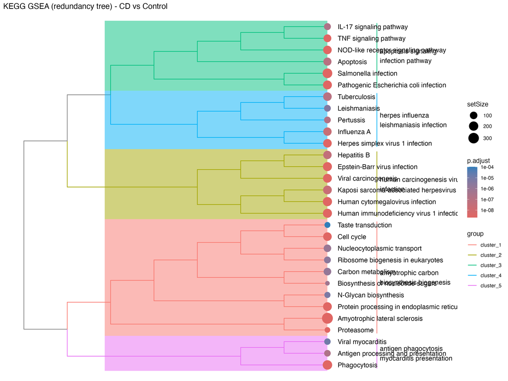

## Biological interpretation

KEGG GSEA highlights a prominent inflammatory signaling component specific to the sensitivity cohort, with enrichment of pathways including IL-17 signaling, TNF signaling and NOD-like receptor signaling - none of which reached significance in the non-inflamed primary cohort. This is consistent with the established involvement of the IL-23/IL-17 axis, TNF-associated inflammatory signaling and NOD2 (the best-characterized Crohn’s disease susceptibility gene) in active disease, and supports the validity of the primary/sensitivity design: the core disease signature is retained across both cohorts, while classic acute inflammatory programs emerge specifically when inflamed tissue is included. This same absence of TNF/IL-17 signal in the primary, non-inflamed cohort is consistent with the detection-threshold limitation already noted for CellChat/LIANA, which likewise did not detect TNF, IFNG, IL17 or TGFB as communication pathways. Several infection-related KEGG pathways are also enriched. These terms should not be interpreted as evidence of active infection, since KEGG infection pathways frequently contain shared host-response genes involved in cytokine signaling, apoptosis, antigen processing and innate immune activation. Their enrichment in this analysis is therefore more appropriately interpreted as evidence of a broad inflammatory host-response program. The presence of cell-cycle and antigen-processing-related pathways further supports the view that the CD transcriptional phenotype involves coordinated immune activation together with cellular and tissue remodeling.

## Hallmarks Collection H

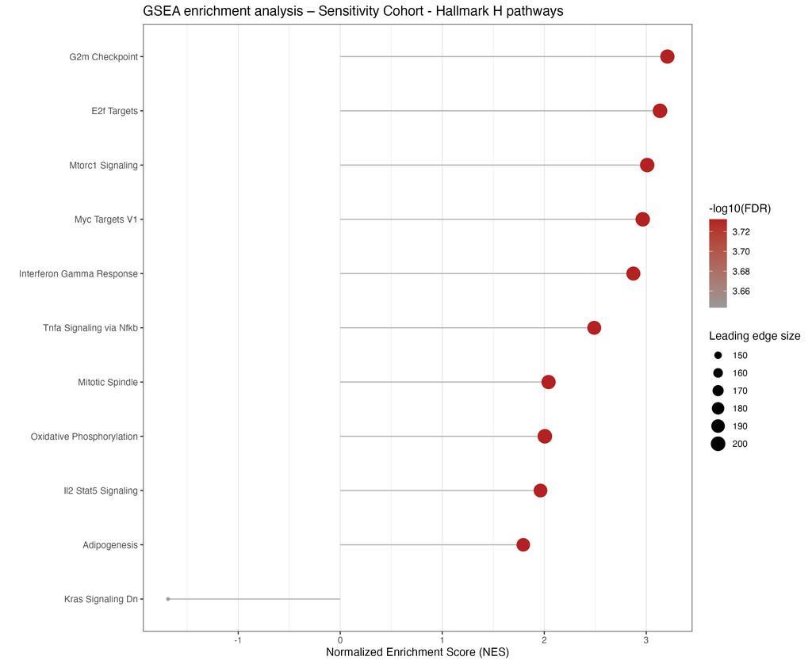

## Biological interpretation

Hallmark GSEA provides the most coherent summary of the sensitivity transcriptional phenotype. The strongest positively enriched programs include G2M checkpoint, E2F targets, MYC targets and mitotic spindle, indicating a prominent proliferative and cell-cycle-associated transcriptional state. This is accompanied by enrichment of mTORC1 signaling and oxidative phosphorylation, suggesting coordinated metabolic activity associated with the altered cellular state. In parallel, Interferon Gamma Response and TNFA Signaling via NFKB are strongly enriched, providing direct evidence of activation of two major inflammatory transcriptional programs in CD tissue. Increased interferon activity has long been documented in Crohn’s disease intestinal immune cells, while NF-kB activation is a well-established feature of the inflammatory intestinal mucosa in CD. IL2-STAT5 signaling is also positively enriched. This is particularly relevant to the broader immune-regulatory phenotype, as IL-2/STAT5 signaling is closely associated with regulatory T-cell biology, and mirrors the same pathway independently identified by GSEA in the LPL-Treg pseudobulk population of this project - a partial, directional cross-cohort convergence rather than a mechanistic replication, since the bulk dataset does not allow this signal to be assigned specifically to Tregs. Overall, the Hallmark results indicate that the CD-associated transcriptional phenotype combines inflammatory signaling, immune regulation, proliferative activity and metabolic remodeling, rather than representing an isolated inflammatory response.

# Complete biological interpretation

The integrated analysis provides convergent evidence that Crohn’s disease is associated with coordinated transcriptional, cellular and intercellular alterations across the intestinal immune compartment. Rather than being driven by a single inflammatory pathway, the results indicate a disease-associated state characterized by immune activation, cytotoxic differentiation, metabolic remodeling, altered cellular composition and reorganization of intercellular communication. At the bulk-tissue level, the GSE193677 analysis provides an independent, tissue-level validation of the disease-associated transcriptional phenotype. The primary cohort, restricted to non-inflamed ileal samples, identified 77 DEGs (23 upregulated and 54 downregulated), whereas the larger sensitivity cohort identified 222 DEGs (127 upregulated and 95 downregulated). The stronger signal in the sensitivity cohort is expected given its larger number of CD samples, although its inclusion of both inflamed and non-inflamed biopsies also introduces greater biological heterogeneity. Importantly, the bulk analysis should be interpreted as a tissue-level validation of pathway activity, rather than as evidence attributable to individual immune cell populations. Notably, the most robust bulk-tissue finding - a coordinated downregulation of a B-cell/plasma-cell/ follicular-help module (CD19, CD79B, MS4A1, PAX5, CR2, FCER2, CXCR5) - has no direct counterpart in the single-cell layer of this project, since B lymphocytes are not part of the profiled IEL/LPL compartments; it is reported here as an orthogonal, hypothesis-generating observation rather than a cross-validated result. The limited ORA signal in the bulk cohorts further supports the use of GSEA as the principal functional readout. In the primary cohort, ORA yielded only isolated enrichment signals, including metabolism of amine-derived hormones in Reactome and xenobiotic metabolism in Hallmark, while several databases returned no significant enrichment. In the sensitivity cohort, ORA remained sparse, with no significant enrichment for several downregulated gene sets. These results should therefore not be interpreted as evidence for absence of biological regulation. Instead, the broader GSEA framework is more informative because it evaluates the ranked transcriptome rather than relying on a relatively small threshold-defined DEG list. The single-cell pseudobulk analysis provides substantially greater biological resolution and identifies a reproducible cytotoxic and metabolic component of the CD phenotype. Across the five statistically eligible cell populations, GNLY was increased in CD in four of five populations, providing gene-level support for the enrichment of cytotoxic/granzyme-associated programs. Conversely, a coherent glucocorticoid/stress-response module comprising FKBP5, TSC22D3, TXNIP, ZFP36L2, NFKBIA and DUSP2 was downregulated across all five populations. This gene-level pattern directly supports the corresponding corticosteroid/glucocorticoid-response signal detected by GSEA in several cell types. The functional enrichment analysis further reveals that oxidative phosphorylation and mitochondrial ATP-production programs represent the most consistent transcriptional feature across the single-cell dataset, being detected across all five eligible populations and across the interrogated gene-set collections. This is particularly relevant because it is observed across both IEL and LPL compartments rather than being restricted to a single lineage. The LPL compartment additionally shows a recurrent translation/ribosome-biogenesis program, whereas IEL populations display more heterogeneous immune and tissue-resident programs. These findings are compatible with the increasing recognition that metabolic state and mitochondrial function are closely coupled to immune-cell activation and intestinal inflammatory states, although the present analysis cannot establish whether the metabolic changes are a cause or consequence of inflammation. Within IEL, the strongest cell-type-specific signal is represented by the TH17-associated inflammatory program. GSEA identifies coordinated enrichment of inflammatory response, IFN-gamma response, IL2–STAT5 signaling and complement-related programs, while the pseudobulk analysis identifies GZMB among the genes supporting this phenotype. This is highly concordant with the original single-cell characterization of the same intestinal system, which identified CD-associated expansion of activated CD39⁺ TH17 cells and described their expression of cytotoxic and inflammatory mediators including GZMB and CCL4. The IEL cytotoxic compartment provides a complementary signal. The analysis identifies increased cytotoxic transcriptional activity together with a marked compositional shift in the cytotoxic/TRM-like population. The reduction of the gamma-delta component within the corresponding population is consistent with the published observation of reduced intestinal gamma-delta T cells in CD. The original Jaeger study also reported broader changes in IEL composition, including reduced CD8⁺, gamma-delta and Treg populations and increased activated TH17 cells in inflamed CD tissue. Thus, the present analysis reproduces several major features of the source tissue biology while providing additional pathway-level resolution. In LPL, the transcriptional phenotype is shifted toward a combination of cytotoxic activation, proliferative/metabolic remodeling and regulatory signaling. Both LPL-Cytotoxic-TRM-like and LPL-Treg populations show the broader metabolic and translational changes identified by GSEA. In particular, IL2–STAT5 signaling is enriched in LPL-Treg, while CellChat identifies IL2 as a CD-associated communication pathway. This represents a useful cross-method convergence, but it should be described as directional convergence rather than direct mechanistic validation, because CellChat identifies an Innate-like/TRM CD8 population as the principal IL2 sender and the receptor configuration is not specifically Treg-selective. The cell–cell communication analyses extend this biological model from intracellular programs to network organization. CellChat identifies increased communication complexity in CD in both IEL and LPL, although the architecture differs between compartments. IEL shows a more diffuse CD network, with substantially more detected pathways but lower average edge strength, whereas LPL shows a proportional increase in both interaction number and total communication strength. This suggests that CD does not simply increase the intensity of one pre-existing signaling circuit; rather, it reorganizes the communication landscape in a compartment-dependent manner. A particularly consistent observation is the emergence of MHC-II-centered communication involving regulatory T-cell populations. In IEL, the dominant MHC-II receiver shifts from a Control-dominant TH17 effector population toward FOXP3⁺ IL2RA⁺ Treg, with additional involvement of TH17-like and macrophage populations. In LPL, MHC-II again undergoes a change in receiving population, with the Control-associated Activated effector Treg profile being replaced by FOXP3⁺ activated Treg and IFN-activated cytotoxic populations in CD. Importantly, these results should be described as population substitution/reorganization rather than simple pathway intensification, because the receiving populations are not equivalent between conditions. This Treg-centered communication phenotype is particularly interesting when considered together with the transcriptional data. GSEA identifies IL2–STAT5 signaling in LPL-Treg, while CellChat identifies MHC-II, MHC-I and IL2 as important components of the LPL communication landscape and GALECTIN, MHC-II and CDH1 as prominent components of the IEL CD profile. Nevertheless, the present dataset does not support the conclusion that Tregs are globally increased or decreased in CD. Indeed, the pseudobulk/scRNA-seq pipeline showed an increased relative Treg representation in CD, whereas the source literature reported reduced Treg proportions in inflamed CD tissue. This discrepancy should remain explicitly acknowledged rather than reconciled by assumption. The compartment-specific communication results provide additional mechanistic resolution. In IEL, the CDH1–CD103 axis is the most biologically specific interaction recovered. The predicted interaction between E-cadherin (CDH1) and CD103 (ITGAE/ITGB7) is consistent with the established role of CD103–E-cadherin interactions in epithelial retention of lymphocytes. However, because the FOXP3⁺ Treg sender is CD-emergent in this dataset, this result should be presented as a CD-specific population characterization rather than a statistically established differential interaction. The original intestinal single-cell study also identified ITGAE expression as a marker of tissue-resident IEL populations, providing additional biological context for this axis. The IEL-specific LIGHT–LTBR axis toward macrophages provides a second compartment-specific feature. LIGHT/TNFSF14 has established roles in intestinal immune regulation, but its biological effects are receptor-dependent and can be either inflammatory or regulatory. Therefore, the present result supports altered LIGHT-mediated communication in CD but does not by itself establish that this interaction is pathogenic. Recent literature similarly emphasizes the context-dependent functions of LIGHT through HVEM and LTBR in intestinal inflammation. In LPL, SIRPG–CD47 communication represents a different form of disease-associated remodeling. The functional-similarity analysis places shared pathways such as MHC-I, CD99, LCK and CypA within a relatively conserved communication core, whereas CD-exclusive pathways occupy a distinct region. SIRP is the pathway showing the largest between-condition distance, supporting a model of network reorganization rather than simple loss of signaling. This interpretation is also consistent with the known role of SIRP-family interactions in T-cell/APC and T-cell/T-cell costimulatory biology, although the present analysis remains transcriptome-based and does not demonstrate receptor activation at the protein level. The apparent absence of canonical inflammatory pathways such as TNF, IFNG, IL17 and TGFB from CellChat should not be interpreted as biological absence. These pathways are prominent in the GSEA and pseudobulk analyses, particularly the IFN-gamma and inflammatory programs in IEL TH17/cytotoxic populations. CellChat inference is dependent on ligand/receptor expression thresholds and the statistical framework used to infer communication probabilities, and therefore has a different detection space from pathway enrichment. This methodological complementarity is important: GSEA detects intracellular transcriptional consequences, whereas CellChat asks whether ligand/receptor expression supports a putative intercellular interaction. CellChat and LIANA should therefore be regarded as complementary rather than interchangeable approaches; systematic benchmarking has demonstrated that ligand–receptor predictions are sensitive to both the inference method and the underlying interaction resource. Taken together, the different analytical layers support a coherent model of CD-associated intestinal immune remodeling. Bulk RNA-seq establishes that the disease-associated transcriptional phenotype is detectable at tissue level; pseudobulk analysis localizes recurrent gene-level changes to specific immune populations; GSEA demonstrates coordinated inflammatory, cytotoxic, metabolic and regulatory programs; and CellChat adds a network-level layer showing that these altered cellular states occur within a reorganized communication landscape. The convergence is particularly strong around cytotoxic activity, IFN-associated inflammation, altered Treg-associated signaling, metabolic remodeling and compartment-specific communication. The resulting model is therefore not one of generalized immune activation alone. Instead, CD appears to involve simultaneous activation of inflammatory/cytotoxic programs, metabolic adaptation, changes in the relative representation and state of intestinal lymphocyte populations, and redistribution of intercellular signaling between these populations. This interpretation is consistent with the established cellular heterogeneity of intestinal CD and with the distinction between IEL and lamina propria immune niches reported in the primary single-cell literature. Finally, these results should be interpreted with the methodological constraints of each layer in mind. The pseudobulk comparisons are based on only two CD and two Control donors per eligible cell type, making GSEA more informative than individual-gene significance alone. CellChat is affected by severe condition-dependent cell-type imbalance, and several of its strongest findings are therefore CD-specific characterizations rather than conventional differential comparisons. LIANA provides an appropriate orthogonal framework for ligand–receptor inference, but specific LIANA concordance should only be added once its final results are explicitly available and verified. These limitations do not invalidate the integrated biological picture; rather, they define which conclusions can currently be considered robust observations and which remain mechanistic hypotheses requiring independent validation. Importantly, the orthogonal communication analysis did not merely increase confidence in the primary findings. In the LPL compartment, LIANA prompted re-examination of the original CellChat MHC-II interpretation and led to correction of an unsupported population- substitution claim. This illustrates the value of integrating independent computational frameworks when interpreting cell–cell communication from single-cell transcriptomic data.

### Cross-validation with cell–cell communication analyses

The single-cell communication analyses provide an orthogonal layer of evidence to the bulk and pseudobulk transcriptional results. LIANA independently reproduced two of the most mechanistically specific CellChat findings: the CDH1–CD103 axis in the IEL compartment and the SIRPG–CD47 axis in LPL. The CDH1–CD103 interaction is consistent with the established role of CD103–E-cadherin binding in the retention and localization of epithelial-resident lymphocytes, whereas SIRPG–CD47 supports a reorganization of T-cell communication in the LPL compartment. These findings provide independent support for the cellular communication changes identified by the primary CellChat analysis.

A particularly strong cross-method convergence was observed for the IL-2 axis in LPL. LIANA identified the high-affinity IL2RA–IL2RB–IL2RG receptor complex preferentially associated with Treg populations, while GSEA independently identified IL2–STAT5 signalling as significantly enriched in the LPL Treg transcriptome in CD. This is concordant with the established biology of constitutive CD25 (IL2RA) expression and high-affinity IL-2 responsiveness in regulatory T cells. Thus, LIANA and GSEA converge on a Treg-centred IL-2 programme, providing stronger evidence than either method alone.

The MHC-II findings also illustrate the value of orthogonal cross-validation. In LPL, LIANA initially appeared to disagree with the CellChat interpretation of a CD-associated change in the receiving Treg population. Direct re-examination of the CellChat object showed, however, that the original claim of absent MHC-II signalling toward Activated effector Treg in CD was not supported by the underlying communication table. The corrected interpretation is therefore a broadening or reorganization of the MHC-II communication repertoire rather than a simple population substitution.

Together, these observations indicate that the CD-associated transcriptional phenotype is accompanied by changes in the cellular communication landscape, particularly involving regulatory T-cell biology, antigen-presentation pathways and tissue-resident lymphocyte interactions. Importantly, the communication analyses are complementary rather than redundant with bulk and pseudobulk transcriptomics: transcriptional enrichment identifies altered cellular programmes, whereas CellChat and LIANA provide information on the potential cellular sources, receivers and organization of ligand–receptor signalling.

# Reproducibility

All analyses were performed in a standardized R environment to ensure full computational reproducibility.

Software environment:

- R version: 4.6.0
- edgeR: 4.10.1
- DESeq2: 1.52.0
- clusterProfiler: 4.20.0
- ReactomePA: 1.56.0
- fgsea: 1.38.0
- msigdbr: 26.1.0
- ComplexHeatmap: 2.28.0

A complete session information log is stored in the `results/logs/` directory of the project repository, enabling full reproducibility of the analysis environment. Reproducibility of stochastic steps was ensured through a fixed random seed (`set.seed(1234)`).

## Limitations and Considerations

**Whole-biopsy resolution.** Both cohorts derive from bulk intestinal biopsies, comprising epithelium, stroma, and all resident immune populations. Cell-type-specific attribution of any signal (e.g., the B-cell module or the LND-like epithelial signature) is not possible without the complementary compartment-resolved scRNA-seq layer of this project, and even there, direct validation is limited to compartments and cell types actually profiled in the source dataset.

**Absence of B-cell populations in the scRNA-seq reference.** The IEL and LPL compartments profiled by single-cell RNA-seq do not include B-lymphocyte or plasma-cell populations. The B-cell/plasma-cell/ follicular module identified here is therefore an orthogonal, hypothesis-generating finding - not a replication of an existing single-cell result - and should be reported as such.

**Undetectable pouch-tissue contamination.** GSE193677 sample metadata does not carry an explicit flag distinguishing native terminal ileum from surgically created ileal pouch tissue, a documented exclusion criterion (n=18 patients) in the original MSCCR cohort description. This cannot be verified or corrected from the public metadata available and is acknowledged as an unresolved, non-quantifiable source of potential heterogeneity within the “Ileum” region label.

**Unmeasured technical covariates.** The original MSCCR processing pipeline adjusted for batch, RIN, rRNA rate, exonic rate, and genetic principal components; none of these are available in the public GEO metadata used here. The limma-voom model in this analysis includes only disease status as a covariate. Residual unmodeled technical variation cannot be excluded as a contributor to the observed transcriptional differences, though the concordance of the two cohorts (primary and sensitivity) and convergence with the independent single-cell layer both argue against this being the dominant driver of the reported signal.

**CellChat/LIANA detection-space mismatch.** The apparent absence of TNF, IFNG, IL17 and TGFB from the CellChat/LIANA cell-cell communication results should not be interpreted as biological absence. These pathways are prominent in both the pseudobulk and the present bulk GSEA (notably IL-17 signaling, TNF signaling pathway and NOD-like receptor signaling, detected specifically in the sensitivity cohort, which includes inflamed tissue). Communication-inference tools depend on ligand/receptor co-expression thresholds and therefore occupy a different detection space than transcriptome-wide enrichment; the two should be read as complementary evidence layers, not as concordant or discordant tests of the same hypothesis.

**Technical exclusion vs biological signal in cohort comparisons.** A subset of Reactome pathways related to collagen chain trimerization, present and significant in the primary cohort, were absent from the sensitivity cohort’s enrichment tables entirely. Gene-level inspection of the leading-edge genes confirmed consistent, non-inverted directionality and stronger significance in the sensitivity cohort, indicating the pathway’s disappearance from the enrichment table reflects a minimum-gene-set-size filtering threshold in that specific run rather than a loss or reversal of biological signal. This illustrates the importance of leading-edge-level verification before interpreting the presence or absence of a pathway across cohort-specific GSEA runs.

**Unresolved Treg directionality.** The pseudobulk/scRNA-seq compositional analysis shows an increased relative Treg proportion in CD (LPL: 0.12 CD vs 0.05 Control), while the source single-cell literature (Jaeger et al., 2021) reports reduced Treg proportions in inflamed CD tissue. This discrepancy is explicitly acknowledged and not resolved by assumption; it may reflect differences in Treg subtype definition, activation state, or sampling between studies, and should be treated as an open question rather than a resolved concordance or contradiction.

**Cross-sectional design.** Both GSE193677 cohorts and the source single-cell dataset are cross-sectional. No causal or temporal ordering between the transcriptional, compositional, and communication-level changes described in this report can be inferred.

**Statistical power heterogeneity across layers.** The pseudobulk single-cell comparisons are based on as few as two CD and two Control donors for the least-represented eligible cell types, in contrast to the 351 CD / 121 Control samples available in the bulk sensitivity cohort. Findings that converge across these very different power regimes (e.g., oxidative phosphorylation, MHC-I) should be weighted more heavily than single-layer observations.

# Deliverables

This analysis produces a complete set of reproducible outputs, including:

- quality-controlled, dataset-specific expression objects
- differential expression result tables (per dataset)
- functional enrichment result tables (ORA and GSEA, per dataset)

## Conclusion

This cross-cohort bulk RNA-seq analysis of GSE193677 provides an independent, tissue-level line of evidence for a coordinated Crohn’s disease transcriptional phenotype, complementing the single-cell pseudobulk, CellChat and LIANA analyses conducted on the primary Jaeger et al. dataset within this project. Three findings stand out as the most robust, cross-validated results of this bulk analysis: (i) a consistent downregulation of a B-cell/plasma-cell/follicular-help gene module (CD19, CD79B, MS4A1, PAX5, CR2, FCER2, CXCR5), reproduced across four independent enrichment databases and both cohorts, and echoed by the complete loss of the LPL-TFH population in the CD scRNA-seq compartment; (ii) an upregulated antimicrobial epithelial signature (LCN2, NOS2, DUOX2) consistent with the recently described CD-specific “LND” epithelial cell population; and (iii) a proliferative/metabolic program (MTORC1, MYC targets, oxidative phosphorylation) that mirrors the “universal” OXPHOS signature independently identified across both IEL and LPL compartments in the single-cell layer.

The comparison between the primary (non-inflamed) and sensitivity (inflamed + non-inflamed) cohorts behaved as expected for this study design: the core disease signature was retained in both, while classic acute inflammatory programs (IL-17 signaling, TNF signaling, NOD-like receptor signaling) emerged specifically in the sensitivity cohort, supporting the validity of the primary cohort as a model of the CD transcriptional baseline independent of active inflammatory status.

Several findings from this bulk analysis are not directly testable against the existing single-cell reference, most notably the B-cell/plasma-cell module, since B lymphocytes are not part of the IEL/LPL compartments profiled by scRNA-seq. These should be regarded as novel, hypothesis-generating results rather than replications, and are flagged as priorities for future compartment-resolved validation (e.g., targeted B-cell/plasma-cell scRNA-seq or spatial transcriptomics of ileal lymphoid follicles).

Taken together with the pseudobulk, CellChat and LIANA analyses, this bulk RNA-seq layer supports a model of Crohn’s disease as a coordinated, multi-program remodeling of the intestinal mucosa - encompassing immune/inflammatory activation, metabolic and proliferative reprogramming, altered cellular composition, and now, at the bulk-tissue level, a previously unexamined suppression of follicular B-cell help - rather than a single dominant inflammatory axis.